# Luteinizing Hormone in Blood Samples:Normal Distribution

- Home
- About
- Writing
- Projects

# Luteinizing Hormone in Blood Samples:Normal Distribution

Richard Lea

2019-01-21

## PDF and CDF

https://www.mathsisfun.com/data/standard-normal-distribution.html

(“Normal Distribution Functions,” n.d.)

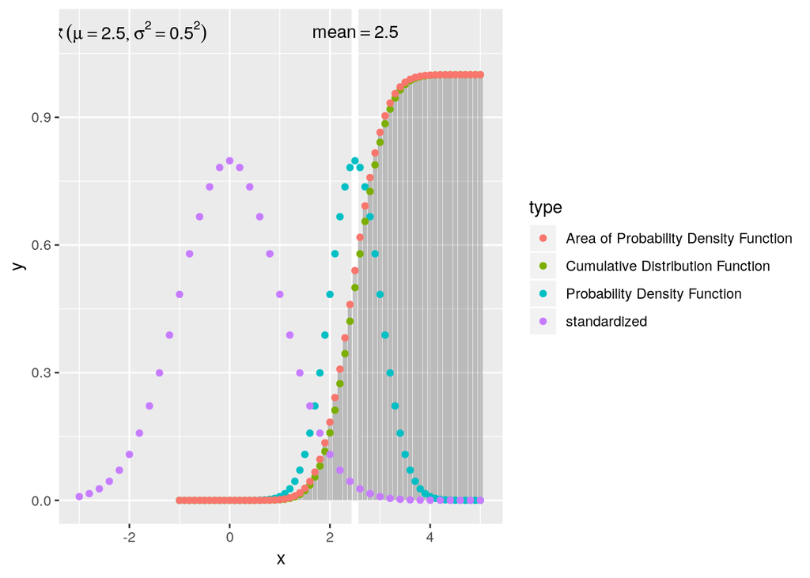

```r
set.seed(10)
(function_mappings <- bind_rows(
  tibble(
    x = seq(-1, 5, by = .1),
    # Choose the mean as 2.5 and SD as 0.5
    y = dnorm(x, mean = 2.5, sd = 0.5),
    type = "Probability Density Function" # PDF
  ),
  tibble(
    x = seq(-1, 5, by = .1),
    # Choose the mean as 2.5 and SD as 0.5
    y = pnorm(x, mean = 2.5, sd = 0.5),
    type = "Cumulative Distribution Function" # CDF
  ),
  tibble(
    x0 = seq(1, 5, by = .1),
    # Choose the mean as 2.5 and SD as 0.5
    y = dnorm(x0, mean = 2.5, sd = 0.5),
    x = (x0 - 2.5) / 0.5,
    type = "standardized"
  ),
  tibble(
    x = seq(-1, 5, by = .1),
    # Choose the mean as 2.5 and SD as 0.5
    p = dnorm(x, mean = 2.5, sd = 0.5),
    y = cumsum(p) * 0.1,
    type = "Area of Probability Density Function" # A(PDF)
  )
)) %>%
  ggplot() + geom_ref_line(v = 2.5) +
  geom_bar(data = filter(
    function_mappings, type == "Area of Probability Density Function"
  ), mapping = aes(x, y), stat = "identity", alpha = 1/3) +
  geom_point(aes(x, y, color = type)) +
  # filter sigma areas
  annotate("text", x = 2.5, y = 1.1, label = "mean == 2.5", parse = TRUE) +
  annotate(
    "text", x = -2, y = 1.1,
    label = "aleph(mu == 2.5, sigma^2 == 0.5 ^ 2)",
    parse = TRUE
  )
```

The probability density of the normal distribution is:

$$f(x | \mu, \sigma^2) =
\frac{1}{\sqrt{2 \pi \sigma^2}} e^{
-\frac{(x - \mu)^2}{2 \sigma^2}
} \\
\begin{align}
&\text{ where } \\
&\mu: \text{ the mean or expectation of the distribution}\\
&\sigma: \text{ the standard deviation }\\
&\sigma^2: \text{ the variance }
\end{align}$$

## Quantile Function

https://en.wikipedia.org/wiki/Quantile_function

Dedicates a inverse cumulative distribution function:

$$F_X:R \rightarrow [0, 1] ~\text{ Cumulative Distribution Function of a random variable } X \\
\text{The quantile Function } Q
\text{ returns a threshold value } x \text{ such that} \\
F_X(x) := Pr(X \leq x) = p ~~ ,\text{ for a probability } p \in (0, 1) \\
\Rightarrow ~ Q(p) = \inf \{ x \in \mathbb{R} : p \leq F(x) \}$$
Here $F_X$ is a normal distribution with density, whose cumulative function is continuous and strictly monotonically increasing, $Q(p)$ could be replaced by:

$$Q = F^{-1} ~~ ,\text{ Quantile function is C.D.F's inverse function }$$

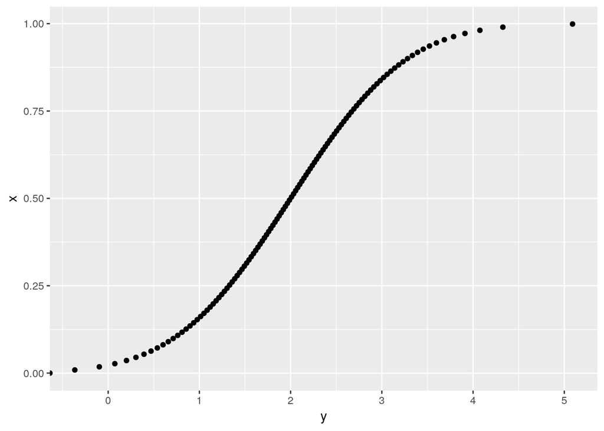

```r
(flipped_quantile <- tibble(
  x = seq(0, 1, by = 0.009),
  y = qnorm(x, mean = 2, sd = 1)
) %>%
  ggplot() + geom_point(aes(y, x)))
```

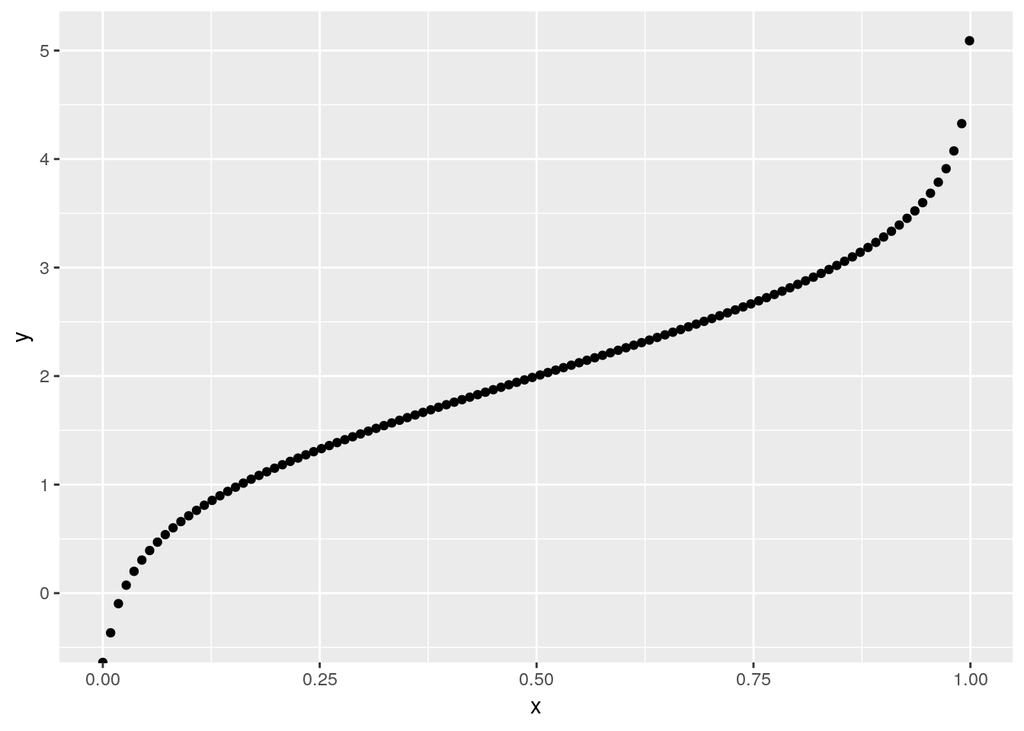

```r
# Visualize the inverse function through coordinates flipping
flipped_quantile + coord_flip()
```

Practically for examples,

- The left under the standard normal curve to the left of zero:
  - $\text{pnorm}(0) = 0.5$
  - $\text{qnorm}(0.5) = 0$
- 1.2815516 is the 90th percentile of the standard normal distribution:
  - $\text{pnorm}(1.2815516) = 0.9$
  - $\text{qnorm}(0.9) = 1.2815516$

## Random Generation for the normal distribution

`rnorm` generates the specified `n` number of random numbers, of which plot the counts with the value of the numbers themselves in the horizontal axis will bring up a bell shape curve as shown below:

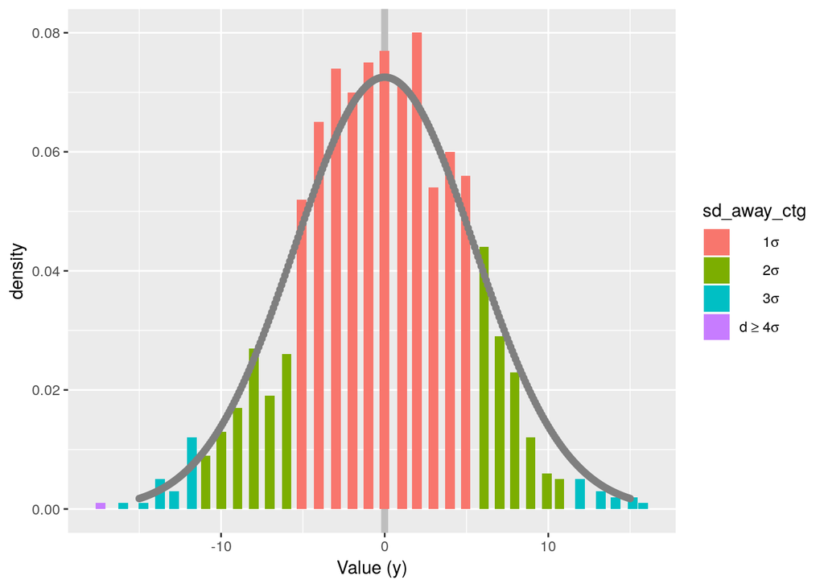

```r
set.seed(70) # Lock the sequence of random
tibble(
  y = rnorm(1000, 0, 5.5),
  sd_away = floor(abs((y - 0) / 5.5))
) %>%
  mutate(bin = cut_width(y, width = 1)) %>% group_by(bin) %>%
  summarise(
    count = n(),
    density = count / 1000,
    sd_away = median(sd_away),
    sd_away_ctg = ifelse(sd_away < 3, paste(sd_away), "OTHER"),
    mean_point = mean(y)
    ) %>%
  ggplot() + geom_ref_line(v = 0, colour = "grey") +
  geom_bar(
    mapping = aes(x = mean_point, y = density, fill = sd_away_ctg), stat = "identity"
  ) +
  geom_point(
    data = tibble(
      x = seq(-15, 15, by = 0.1),
      y = dnorm(x, mean = 0, sd = 5.5)
    ),
    mapping = aes(x = x, y = y),
    color = "grey50"
  ) + scale_fill_discrete(
    breaks = c("0", "1", "2", "OTHER"),
    labels = c(expression(1 * sigma), expression(2 * sigma), expression(3 * sigma), expression(d >= 4 * sigma))
  ) + xlab("Value (y)")
```

Visualize randoms:

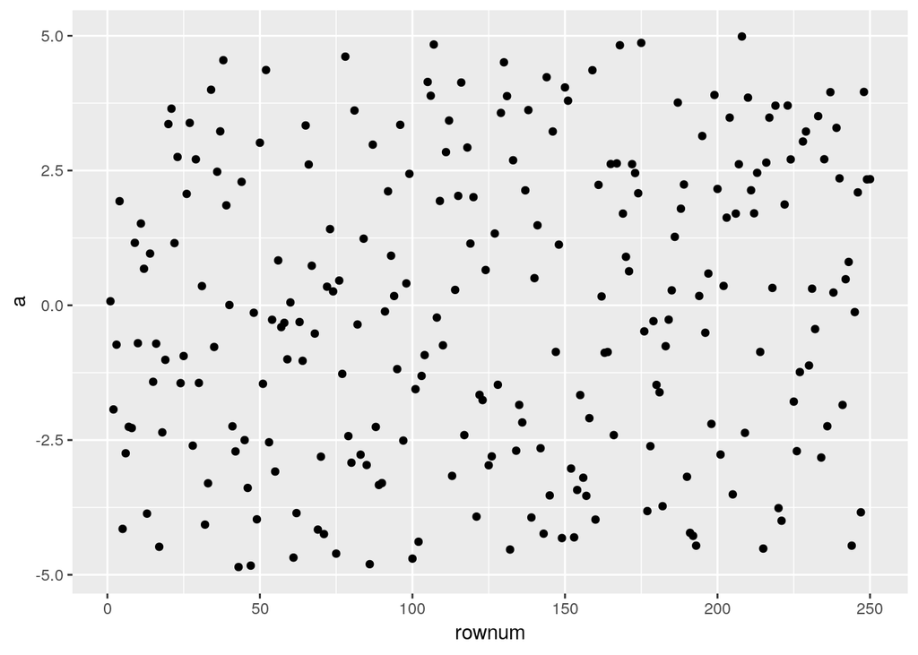

```r
set.seed(10)
tibble(
  a = runif(250, -5, 5)
) %>%
  mutate(rownum = row_number()) %>%
  ggplot() + geom_point(aes(rownum, a))
```

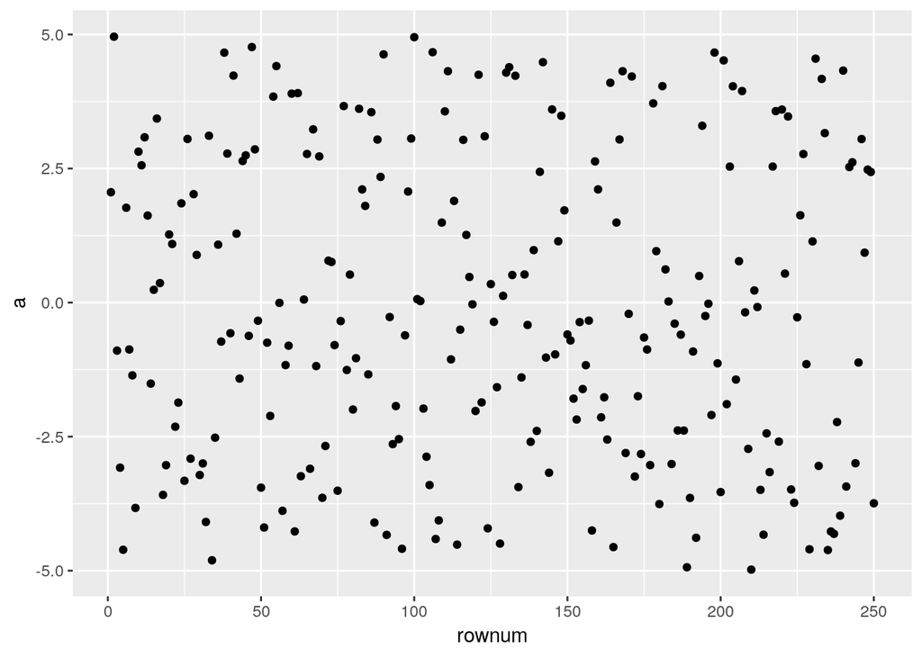

```r
set.seed(6000)
tibble(
  a = runif(250, -5, 5)
) %>%
  mutate(rownum = row_number()) %>%
  ggplot() + geom_point(aes(rownum, a))
```

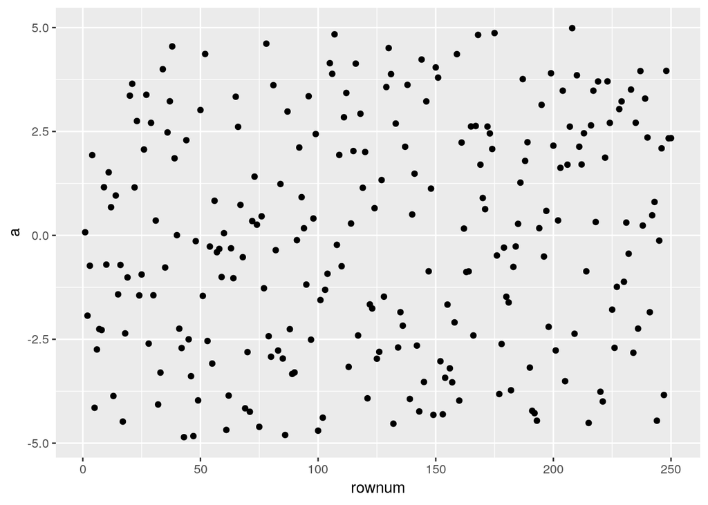

```r
set.seed(10)  # The Random with the seed of 10 could be reproduced
tibble(
  a = runif(250, -5, 5)
) %>%
  mutate(rownum = row_number()) %>%
  ggplot() + geom_point(aes(rownum, a))
```

## Random Generation for Student’s t distribution

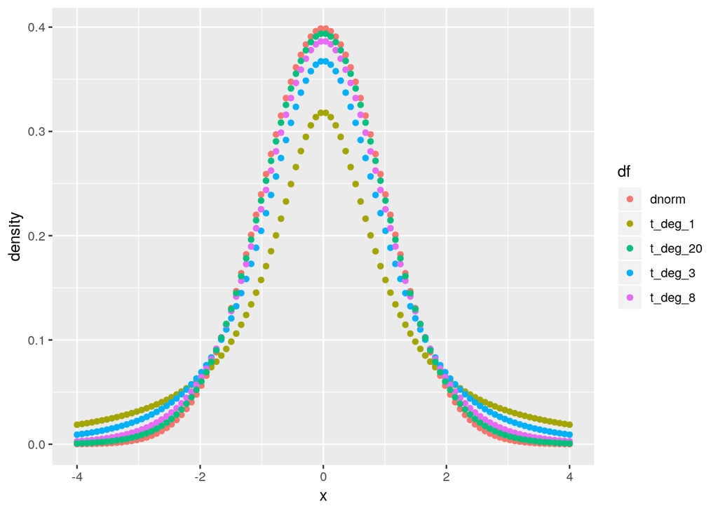

```r
set.seed(10)
tibble(
  x = seq(-4, 4, length.out = 100),
  dnorm = dnorm(x),
  t_deg_1 = dt(x, 1), # Choose the degrees of freedom as 1
  t_deg_3 = dt(x, 3), # Choose the degrees of freedom as 3
  t_deg_8 = dt(x, 8), # Choose the degrees of freedom as 8
  t_deg_20 = dt(x, 20)# Choose the degrees of freedom as 20
) %>%
  gather(
    dnorm, t_deg_1, t_deg_3, t_deg_8, t_deg_20,
    key = "df", value = "density") %>%
  ggplot() + geom_point(aes(x, `density`, color = df))
```

The probability density function of a student’s t distribution is:

$$\begin{align}
f(t) &= \frac{\Gamma(\frac{\nu+1}{2})}{\sqrt{\nu \pi} \Gamma(\frac{\nu}{2})}
(1 + \frac{t^2}{\nu})^{-\frac{\nu + 1}{2}} \\
&= \frac{1}{\sqrt{\nu}~\textbf{B}(\frac{1}{2}, \frac{1}{2})}
(1 + \frac{t^2}{\nu})^{-\frac{\nu + 1}{2}}
\end{align}$$
where

- $\nu$ is the number of degrees of freedom
- $\Gamma$ is the gamma function
- $\textbf{B}$ is the Beta Function

## Luteinzing Hormone in Blood Samples

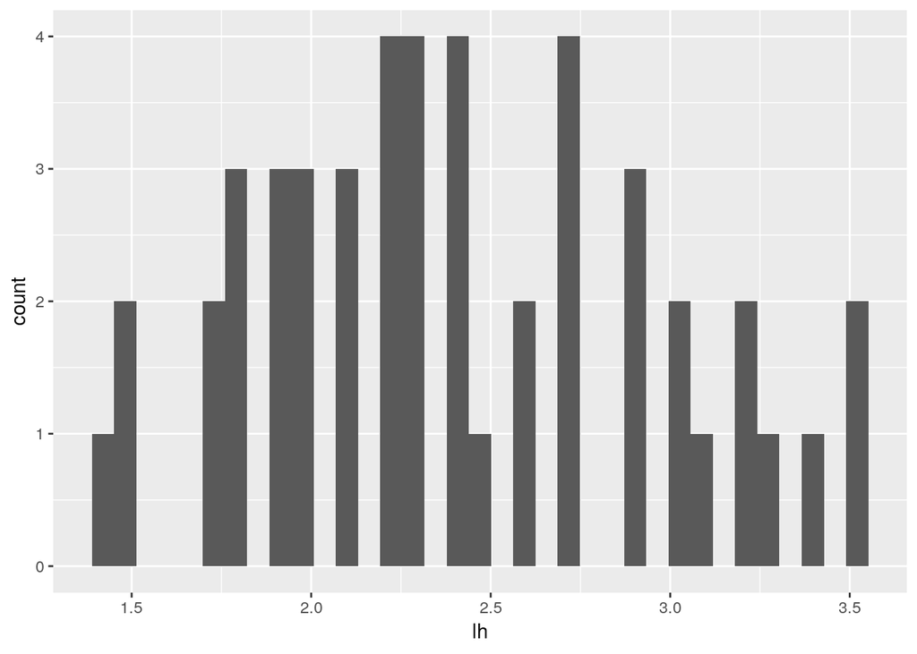

```r
# Check the normality of this dataset
tibble(lh = datasets::lh, time = 1:48) %>%
  ggplot() + geom_histogram(aes(x = lh), bins = 35)
```

## References

“Normal Distribution Functions.” n.d. https://www.r-bloggers.com/normal-distribution-functions/.

Menu Share